# R Notebook

# Week 6 Lab : Sample Size and the importance of randomness

This week’s lab is about experimental design in regards to the size, set-up, and analysis of the group, or sample, we are interested in. We’ll think about how selection into treatment and control conditions impact the results and how random assignment works.

In this lab we will cover:

- Review of ggplot techniques and introduction of the stat_summary function
- Visualizing Experimental Designs
- Tools for Random Selection and Random Assignment.

**DATA:** We will use a dataset that includes information about California Schools. This is a R learning data set. The data is from K-6 or K-8 schools in 1998-1999. It includes the following variables, all totaled and averaged at the district level:

- district, school, and county
- grades: Whether the school is K-6 or K-8
- students: total number of students enrolled
- teachers: total number of teachers
- calworks: number of students who qualify for an income assistance program
- lunch: number of students who qualify for reduced-price lunch
- computer: number of computers in the school
- expenditure: per student
- income: average income (in 1,000s)
- english: percent of students learning English (English as a second language)
- read & math: average scores per subject (CA standardized test administered to 5th graders)

### Load Packages and Data

|  | district | school | county | grades | students | teachers | calworks | lunch | computer | expenditure | income | english | read | math |
| --- | --- | --- | --- | --- | --- | --- | --- | --- | --- | --- | --- | --- | --- | --- |
| 1 | 75119 | Sunol Glen Unified | Alameda | KK-08 | 195 | 10.90 | 0.5102 | 2.0408 | 67 | 6384.911 | 22.690001 | 0.000000 | 691.6 | 690.0 |
| 2 | 61499 | Manzanita Elementary | Butte | KK-08 | 240 | 11.15 | 15.4167 | 47.9167 | 101 | 5099.381 | 9.824000 | 4.583333 | 660.5 | 661.9 |
| 3 | 61549 | Thermalito Union Elementary | Butte | KK-08 | 1550 | 82.90 | 55.0323 | 76.3226 | 169 | 5501.955 | 8.978000 | 30.000002 | 636.3 | 650.9 |
| 4 | 61457 | Golden Feather Union Elementary | Butte | KK-08 | 243 | 14.00 | 36.4754 | 77.0492 | 85 | 7101.831 | 8.978000 | 0.000000 | 651.9 | 643.5 |
| 5 | 61523 | Palermo Union Elementary | Butte | KK-08 | 1335 | 71.50 | 33.1086 | 78.4270 | 171 | 5235.988 | 9.080333 | 13.857677 | 641.8 | 639.9 |

Let’s say that we want to run a field experiment in these districts. How would we decide what schools get the treatment and which are our controls? What impact does this decision have on the distribution of the school demographics?

### Non-Random Example: Self-Selection

- Review Tuesdays’ Why Experimentation Lecture for another example*

Imagine that we will allow our schools to self-select into treatment for an experiment on reading scores. For some reason the schools with the most teachers all select into our treatment.

```r
median(CASchools$teachers)
```

```
[1] 48.565
```

There’s a median of 48.5 teachers so we’ll say schools with more than 50 teachers opted in.

```r
table(CASchools$treatment)
```

```
  0   1
212 208
```

We have 208 schools in our treatment group and 212 schools in our control group.

Now we run a series of correlations to see what this self selection does to our design:

```r
# Reading and Treatment
cor(CASchools$read, CASchools$treatment)
```

```
[1] -0.07944573
```

Despite no treatment having taken place we still find a correlation between our outcome (reading score) and our treatment.

## Non-Random Example 2:

```r
# Reading and Treatment
cor(CASchools$read, CASchools$treatment2)
```

```
[1] -0.7808384
```

We still find correlations between the treatment and outcome measures and the teachers and treatment, even though our choice was seeemingly arbitrary.

Looking at other characteristics:

```r
CASchools %>%
  group_by(treatment2) %>%
  summarize(math=mean(math), lunch=mean(lunch), computer=mean(computer))
```

| treatment2 | math | lunch | computer |
| --- | --- | --- | --- |
| 0 | 667.9029 | 25.08540 | 270.8905 |
| 1 | 638.7824 | 64.32507 | 335.8762 |

### Random Assignment

Now let’s see if we can remove these corrlations among covariates by using random assignment. We’ll use the randomizr package for this.

```r
table(CASchools$treatmentR)
```

```
  0   1
212 208
```

Correlations:

```r
#what correlations persist?
# Teachers and Treatment
cor(CASchools$teachers, CASchools$treatmentR)
```

```
[1] -0.01056672
```

Other variables:

```r
CASchools %>%
  group_by(treatmentR) %>%
  summarize(math=mean(math), lunch=mean(lunch), computer=mean(computer))
```

| treatmentR | math | lunch | computer |
| --- | --- | --- | --- |
| 0 | 654.9495 | 43.74748 | 321.3962 |
| 1 | 651.7048 | 45.68141 | 285.0240 |

We still find a very small correlation, even though we’ve done random assignment? Why?

### Effects of Sample Size

As sample size increases, randomization will bring the differences between our two groups closer to 0. Since we’ve been using the full data set of schools, we will thus look at what happens when we randomly select 100 schools, out of the total 420, to be in our study. What do you predict will occur with our randomization? With the differences between other characteristics?

```r
table(caschools$selected)
```

```
  1
100
```

Now that we have our random selection of 100 schools, we’ll randomly assign each school to treatment and control and rerun the correlations

```r
# Reading and Treatment
cor(caschools$read, caschools$treatmentR)
```

```
[1] -0.2647552
```

How is this case (N=100) different than the earlier case (N=420)?

# Visualizing Experimental Results

### Control + Treatment Plots

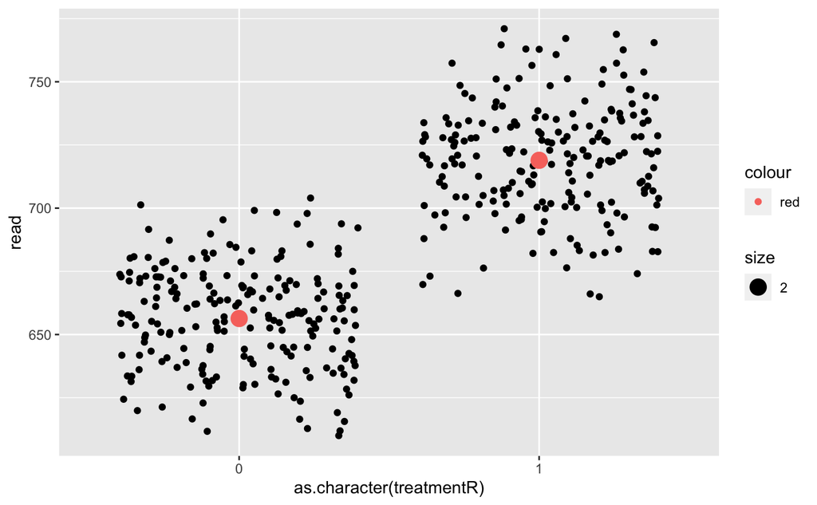

### 2x2 Factorial Design

Effect of homework and time spent in class on Math scores

2 x 2 Design: 1 extra hour classtime - 1 hour of homework Math  
1 extra hour classtime - No homework no extra classtime - 1 hour of Homework no extra classtime - No homework

We’ll call the 1 extra hour of classtime our treatmentR from above and then make a new variable (treatmentH) for the homework.

```r
table(caschools_fact$treatmentH, caschools_fact$treatmentR) # row then column.
```

```
      0   1
  0 106 104
  1 106 104
```

### Visualizing the Null Case

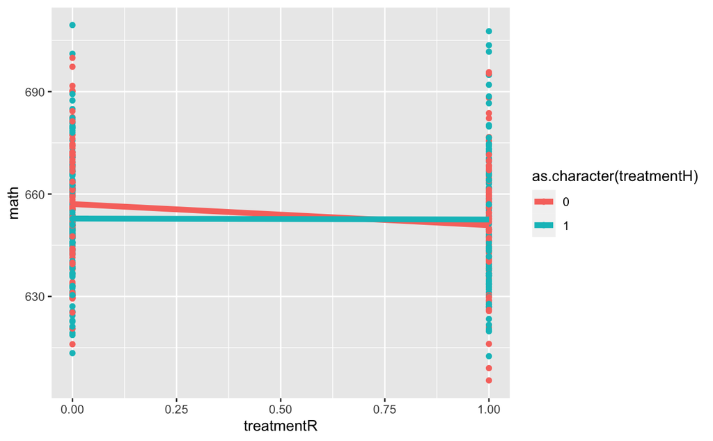

### Visualizing a main effect

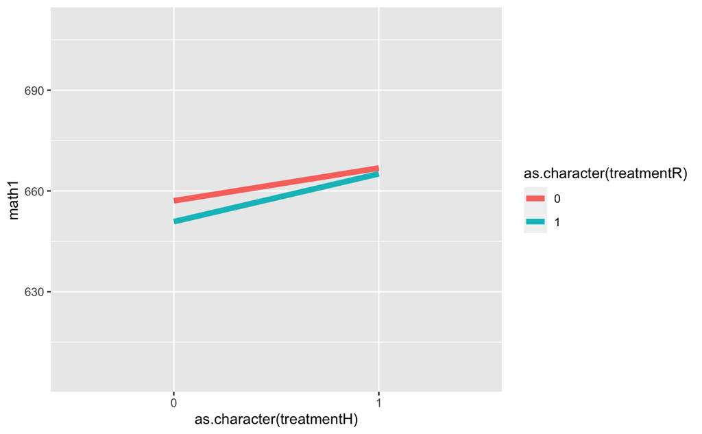